# ARIMA Forecasting of Bangus Prices

January 24, 2022

This IPython notebook details the step-by-step process of creating an ARIMA model for forecasting bangus prices.

Abstract: The COVID-19 pandemic has impacted the over all economy in many sectors such as agriculture. In this study, the researcher analyzes the prices of fish commodities being sold in Metro Manila during the pandemic lockdowns. Using the relevant time series methodologies such as the Autoregressive Integrated Moving Average (ARIMA), the researcher establishes the hypothesis that the COVID-19 lockdowns have an impact on these prices. Based on the study’s findings, the fish commodities were affected by the lockdowns in specified months and even in the entire duration of the lockdown from October 1, 2019 to August 31, 2021.

Datasets from: https://www.da.gov.ph/price-monitoring/  
Range of dataset used: **October 01, 2019 - August 31, 2021**

- Python Modules
- Reading the parsed data
- Visualizing the data
- Developing the ARIMA Model
- Testing for stationarity
- Differencing observations by an order of one
- Retesting differenced observations
- Determining autoregression and moving average terms
- ARIMA(0,1,1) fitting and summary
- Forecast fitting and visualization
- Diagnosing ARIMA model residuals
- Evaluating the ARIMA Model with RMSE
- Discussion of the results

### Python Modules

```python
# Standard data processing modules
import numpy as np
import pandas as pd
import matplotlib.pyplot as plt
from datetime import datetime

# Statistical testing modules
from statsmodels.tsa.stattools import adfuller
from pandas.plotting import autocorrelation_plot
from statsmodels.graphics.tsaplots import plot_acf, plot_pacf
from statsmodels.tsa.arima.model import ARIMA

# Additional math modules
from sklearn.metrics import mean_squared_error
from math import sqrt

# Remove unnecessary warnings
import warnings
warnings.filterwarnings('ignore')
warnings.simplefilter('ignore')
```

### Reading the parsed data

```python
# Reading Csv
bangus_df = pd.read_csv('C:\\Users\\infot\\Desktop\\data analytics\\data analytics scripts\\fixed csv\\bangus.csv', parse_dates=[0], index_col=0)

# Pandas and Matplotlib plotting fix
pd.plotting.register_matplotlib_converters()
```

### Visualizing the data

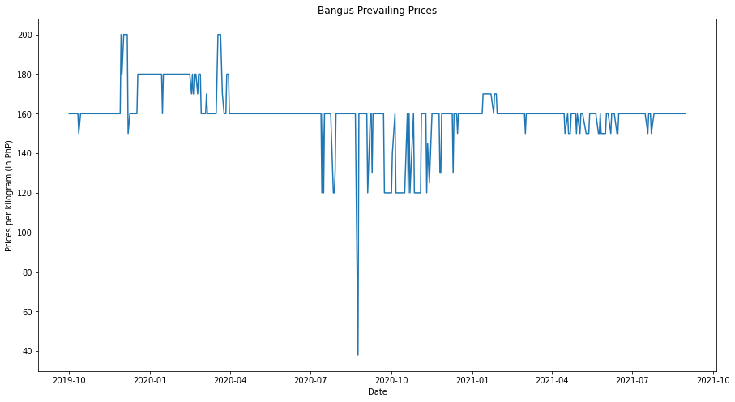

```python
fig, ax = plt.subplots(figsize=(15, 8))
ax.set(title = "Bangus Prevailing Prices", xlabel = "Date", ylabel = "Prices per kilogram (in PhP)")
ax.plot(bangus_df)
plt.show()
```

```python
bangus_df.head()
```

|  | prevailing |
| --- | --- |
| 2019-10-01 | 160.0 |
| 2019-10-02 | 160.0 |
| 2019-10-03 | 160.0 |
| 2019-10-04 | 160.0 |
| 2019-10-05 | 160.0 |

```python
bangus_df.tail()
```

|  | prevailing |
| --- | --- |
| 2021-08-26 | 160.0 |
| 2021-08-27 | 160.0 |
| 2021-08-28 | 160.0 |
| 2021-08-30 | 160.0 |
| 2021-08-31 | 160.0 |

## Developing the ARIMA Model

The ARIMA model is a generalized autoregression and moving average model used in time-series analysis. The model requires the necessity the analyze for the number of autoregression terms, nonseasonal differences for stationarity, and moving average terms.

#### Construction of an ARIMA Model

1. Stationarizing the series by differencing
2. Analyzing the autocorrelations and partial autocorrelations to determine the number of autoregression and moving average terms
3. Fitting the model and diagnosing residuals
4. Adjusting the number of autogression and moving average terms if necessary

For this model, it is necessary to determine if the time-series inputs are stationary. A stationary time-series is one whose process does not depend on time. Specifically, having the properties of constant mean and constant variance as the time-series goes on.

### Testing for stationarity

For this time-series, the researcher will use the Augmented Dicky-Fuller test for stationarity. The Augmented Dicky-Fuller test is a common unit root test for determining stationarity that includes a high order autoregressive process compared to its counterpart, the Dicky-Fuller test. Both these tests assume are used to determine if a time-series has a unit root, a characteristic of time-series to be non-stationary

#### The usual hypotheses for this test are:

Ho: The time-series has a unit root. It is non-stationary  
H1: The time-series is stationary

The result of this test reveals that time-series is non-stationary. Therefore, it is necessary to difference the series until it is stationary.

```python
# Defining ADF function
def adfuller_test(dataframe):
    result=adfuller(dataframe)
    labels = ['ADF Test Statistic','p-value','Number of Lags Used','Number of Observations Used']
    for value, label in zip(result, labels):
        print(label+' : '+str(value) )
    if result[1] <= 0.05:
        print("Strong evidence against the null hypothesis(Ho). Therefore, reject the null hypothesis. Data has no unit root and is stationary")
    else:
        print("Weak evidence against null hypothesis. The time series has a unit root, indicating it is non-stationary")
```

```python
# Calling the ADF function
adfuller_test(bangus_df['prevailing'])
```

```
ADF Test Statistic : -2.3881410382716295
p-value : 0.14511152594044863
Number of Lags Used : 13
Number of Observations Used : 587
Weak evidence against null hypothesis. The time series has a unit root, indicating it is non-stationary
```

### Differencing observations by an order of one

```python
bangus_stationary = bangus_df.diff().dropna()
```

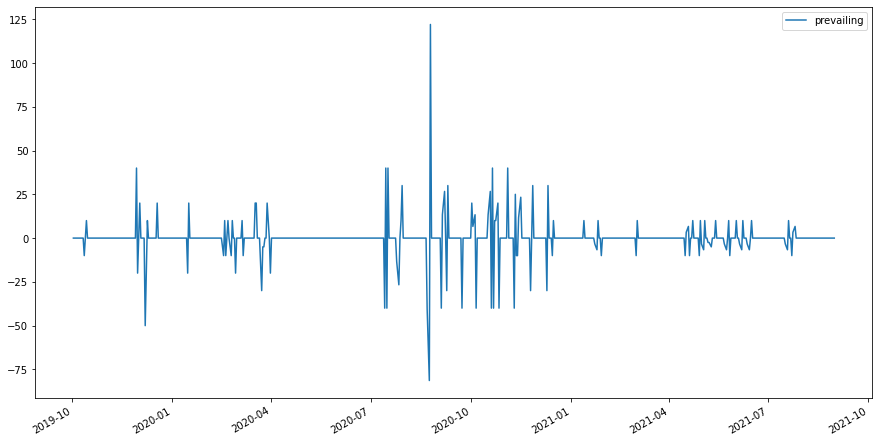

```python
bangus_stationary.plot(figsize=(15, 8))
```

```python
bangus_stationary.head()
```

|  | prevailing |
| --- | --- |
| 2019-10-02 | 0.0 |
| 2019-10-03 | 0.0 |
| 2019-10-04 | 0.0 |
| 2019-10-05 | 0.0 |
| 2019-10-07 | 0.0 |

### Retesting differenced observations

```python
adfuller_test(bangus_stationary['prevailing'])
```

```
ADF Test Statistic : -10.99982990979575
p-value : 6.725977428781277e-20
Number of Lags Used : 12
Number of Observations Used : 587
Strong evidence against the null hypothesis(Ho). Therefore, reject the null hypothesis. Data has no unit root and is stationary
```

### Determining autoregression and moving average terms

A systematic way of determining the AR and MA terms of an ARIMA model is by looking at the autocorrelation and partial autocorrelation plots of the time-series. In general, there are a few rules that can be used for identifying the proper ARIMA model using the ACF and PACF plots:

- If the partial autocorrelation function (PACF) of the differenced series displays a sharp cutoff and/or the lag-1 autocorrelation is positive--i.e., if the series appears slightly "underdifferenced"--then consider adding one or more AR terms to the model. The lag beyond which the PACF cuts off is the indicated number of AR terms.
- If the autocorrelation function (ACF) of the differenced series displays a sharp cutoff and/or the lag-1 autocorrelation is negative--i.e., if the series appears slightly "overdifferenced"--then consider adding an MA term to the model. The lag beyond which the ACF cuts off is the indicated number of MA terms.
- It is possible for an AR term and an MA term to cancel each other's effects, so if a mixed AR-MA model seems to fit the data, also try a model with one fewer AR term and one fewer MA term--particularly if the parameter estimates in the original model require more than 10 iterations to converge. BEWARE OF USING MULTIPLE AR TERMS AND MULTIPLE MA TERMS IN THE SAME MODEL.
- If there is a unit root in the AR part of the model--i.e., if the sum of the AR coefficients is almost exactly 1--you should reduce the number of AR terms by one and increase the order of differencing by one.
- If there is a unit root in the MA part of the model--i.e., if the sum of the MA coefficients is almost exactly 1--you should reduce the number of MA terms by one and reduce the order of differencing by one.
- If the long-term forecasts appear erratic or unstable, there may be a unit root in the AR or MA coefficients.

For this time-series, the lag-1 correlation is negative and the ACF displays a sharper cutoff. The ARIMA model can include MA(1) term.

#### Plotting autocorrelation function of differenced observations

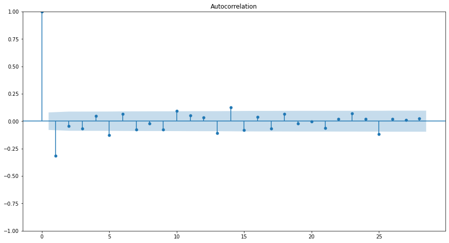

```python
fig, ax = plt.subplots(figsize=(15, 8))
ax.set(title = "Autocorrelation")
plot_acf(bangus_stationary, ax=ax)
plt.show()
```

#### Plotting partial autocorrelation function of differenced observations

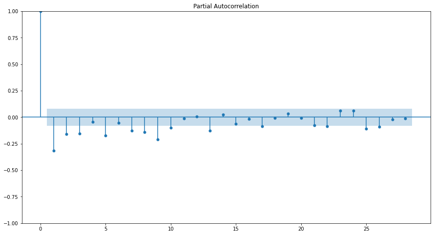

```python
fig, ax = plt.subplots(figsize=(15, 8))
ax.set(title = "Partial Autocorrelation")
plot_pacf(bangus_stationary, ax=ax)
plt.show()
```

### ARIMA(0,1,1) fitting and summary

The model is determined to have one order of differencing and one moving average terms. The result summary shows that the moving average terms are significant and the model does not show a lack of good fit--in other words, the model is fine

```python
model = ARIMA(bangus_df, order=(0,1,1))
model_fit = model.fit()
model_fit.summary()
```

SARIMAX Results

| Dep. Variable: | prevailing | No. Observations: | 601 |
| --- | --- | --- | --- |
| Model: | ARIMA(0, 1, 1) | Log Likelihood | -2227.344 |
| Date: | Sun, 30 Jan 2022 | AIC | 4458.689 |
| Time: | 21:04:59 | BIC | 4467.482 |
| Sample: | 0 | HQIC | 4462.112 |
|  | - 601 |  |  |
| Covariance Type: | opg |  |  |

|  | coef | std err | z | P>\|z\| | [0.025 | 0.975] |
| --- | --- | --- | --- | --- | --- | --- |
| ma.L1 | -0.4841 | 0.009 | -51.018 | 0.000 | -0.503 | -0.466 |
| sigma2 | 98.1168 | 1.490 | 65.833 | 0.000 | 95.196 | 101.038 |

| Ljung-Box (L1) (Q): | 3.26 | Jarque-Bera (JB): | 18463.06 |
| --- | --- | --- | --- |
| Prob(Q): | 0.07 | Prob(JB): | 0.00 |
| Heteroskedasticity (H): | 0.20 | Skew: | -1.56 |
| Prob(H) (two-sided): | 0.00 | Kurtosis: | 30.00 |

Warnings:  
[1] Covariance matrix calculated using the outer product of gradients (complex-step).

### Forecast fitting and visualization

The forecast is dated from the last period of the actual observation to today (January 24, 2022)

```python
# Training data fit
bangus_df['training'] = model_fit.predict(start=datetime(2019,10,2), end=datetime(2021,8,31))
bangus_df.at['2019-10-01', 'training'] = bangus_df['prevailing'].mean()
```

```python
# Setting frequency offset
week = "Mon Tue Wed Thu Fri Sat"
nosun = pd.offsets.CustomBusinessDay(weekmask=week)

# Make daterange of forecast dates
idx = pd.date_range(start = '2021-08-31', end = '2022-01-24', freq = nosun)

# Fit model predictions
future = model_fit.get_forecast(126)

# Format as dataframe
future_df = pd.DataFrame(future.predicted_mean)
future_df['date'] = idx
future_df = future_df.set_index('date')
future_df.columns = ['forecast']
```

```python
conf_df = pd.DataFrame(future.conf_int(alpha=0.05))
conf_df['date'] = idx
conf_df = conf_df.set_index('date')
conf_df.columns = ['lower bound', 'upper bound']
```

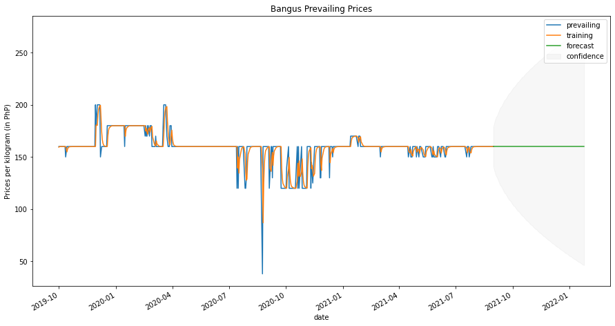

```python
fig, ax = plt.subplots(figsize=(15, 8))
ax.set(title = "Bangus Prevailing Prices", xlabel = "Date", ylabel = "Prices per kilogram (in PhP)")
bangus_df.plot(ax=ax)
future_df.plot(ax=ax)
plt.fill_between(idx, conf_df['lower bound'], conf_df['upper bound'], color="dimgray",alpha=0.05, label="confidence")
plt.legend(loc='best')
plt.show()
```

```python
future_df.head()
```

| date | forecast |
| --- | --- |
| 2021-08-31 | 160.0 |
| 2021-09-01 | 160.0 |
| 2021-09-02 | 160.0 |
| 2021-09-03 | 160.0 |
| 2021-09-04 | 160.0 |

```python
future_df.tail()
```

| date | forecast |
| --- | --- |
| 2022-01-19 | 160.0 |
| 2022-01-20 | 160.0 |
| 2022-01-21 | 160.0 |
| 2022-01-22 | 160.0 |
| 2022-01-24 | 160.0 |

### Diagnosing ARIMA model residuals

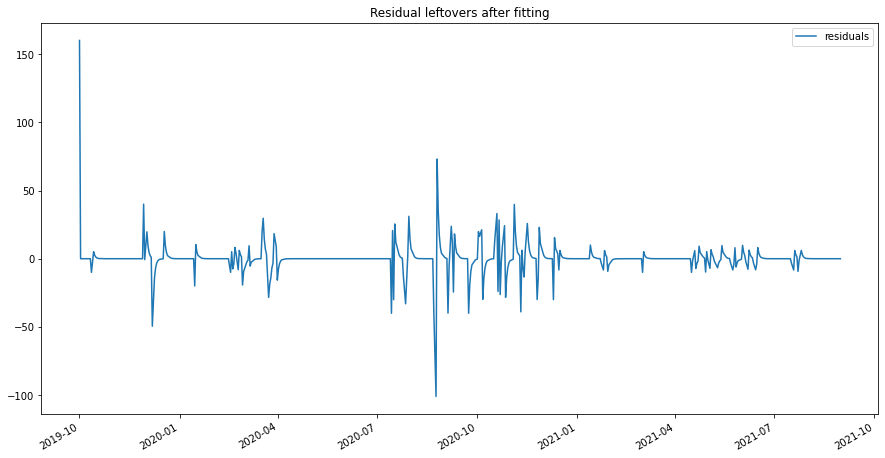

```python
residuals = pd.DataFrame(model_fit.resid)
residuals.columns = ['residuals']
residuals.plot(figsize=(15, 8), title="Residual leftovers after fitting")
plt.show()
```

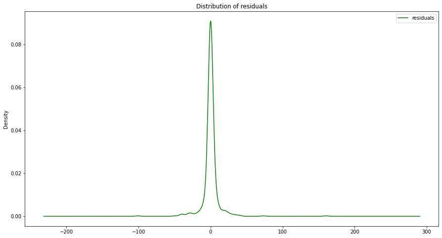

```python
residuals.plot.kde(figsize=(15, 8), color="green", title="Distribution of residuals")
plt.show()
```

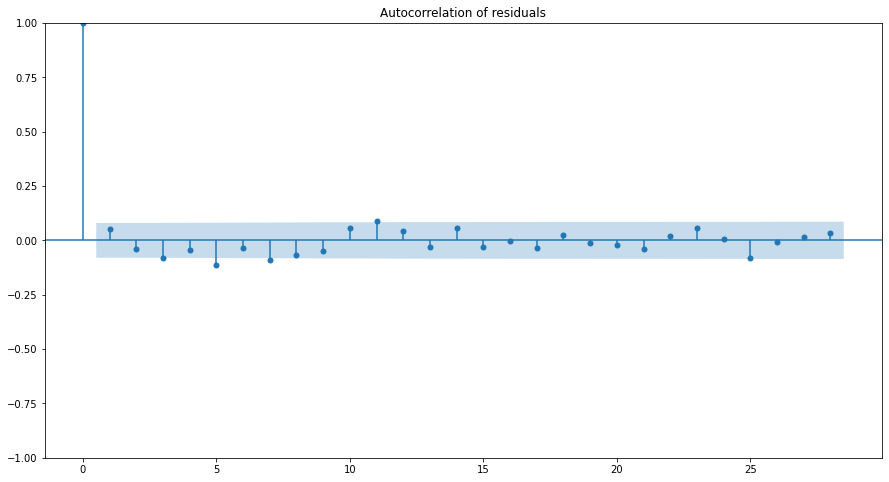

```python
fig, ax = plt.subplots(figsize=(15, 8))
#ax.set(title = "Autocorrelation of residuals")
plot_acf(residuals, title = "Autocorrelation of residuals", ax=ax)
plt.show()
```

```python
print(residuals.describe())
```

```
        residuals
count  601.000000
mean     0.266245
std     11.862229
min   -101.020904
25%     -0.000033
50%      0.000005
75%      0.330085
max    160.000000
```

### Evaluating the ARIMA Model with RMSE

The root mean squared error shows 9.90 which is minimal enough to prove for accuracy

```python
mse = mean_squared_error(bangus_df['prevailing'], bangus_df['training'])
rmse = sqrt(mse)
print('RMSE value: %f' % rmse)
```

```
RMSE value: 9.897181
```

### Discussion of the results

- The autocorrelation of the residuals show almost no significant values.
- The RMSE shows minimal error
- The Ljung-Box test accepts the null hypothesis indiciating good fit
- The other parts of the summary indicates that the moving average term is significant

This result implies that ARIMA(0,1,1) is a good fit for forecasting fish prices during the even accounting for the pandemic lockdowns.